# 統計學習與深度學習作業二 B09303047林奕霆

## 第二題

```python
# Q2.1
import pickle
from sklearn.linear_model import LogisticRegression
import numpy as np
import matplotlib.pyplot as plt
%matplotlib inline

# load dataset
dsfile = 'adult_m50k.pickle'
with open(dsfile, 'rb') as fh1:
    adult50kp = pickle.load(fh1)

#train prediction model
c = 0.3
lr2 = LogisticRegression(solver = 'lbfgs', C= c, max_iter = 1000)
lr2.fit(adult50kp['x_train'], adult50kp['y_train'])
#make prediction
ypred = lr2.predict(adult50kp['x_test'])
ypredprob = lr2.predict_proba(adult50kp['x_test'])
#compute accuracy
ncorrect = np.sum(adult50kp['y_test'] == ypred)
accuracy_sk = ncorrect / adult50kp['y_test'].shape[0]
print("Accuracy = %f" % accuracy_sk)

#取出y_test以及預測為positive的機率
Y_test = adult50kp['y_test']
ypredprob_pos = np.delete(ypredprob, 0, 1)
ypredprob_list1 = ypredprob_pos.tolist()
ypredprob_list = sorted(ypredprob_list1)
```

```
Accuracy = 0.848340
```

```python
def roc_calculate(y_predprob, y_test, threshold_num, ypredproblist):
    tprlist = []
    fprlist = []
    for k in range(threshold_num):
        tp = 0
        fp = 0
        tn = 0
        fn = 0
        for i in range(threshold_num):
            if(y_predprob[i] >= ypredproblist[k]):
                if(y_test[i] == 1):
                    tp += 1
                else:
                    fp += 1
            elif(y_predprob[i] < ypredproblist[k]):
                if(y_test[i] == 0):
                    tn += 1
                else:
                    fn += 1
        tpr = tp/(tp+fn)
        fpr = fp/(fp+tn)
        tprlist.append(tpr)
        fprlist.append(fpr)
    return(tprlist, fprlist)
tpr, fpr = roc_calculate(ypredprob_pos, Y_test, Y_test.shape[0], ypredprob_list)
```

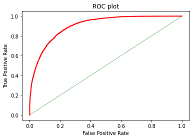

```python
plt.plot(fpr, tpr, 'r', lw=2)
plt.plot([0, 1], [0, 1], 'g', lw=0.5)
plt.title('ROC plot')
plt.xlabel('False Positive Rate')
plt.ylabel('True Positive Rate')
```

```python
# Q3.2
auc = abs(np.trapz(tpr,fpr))
print(auc)
```

```
0.9034935168443091
```

## 第三題

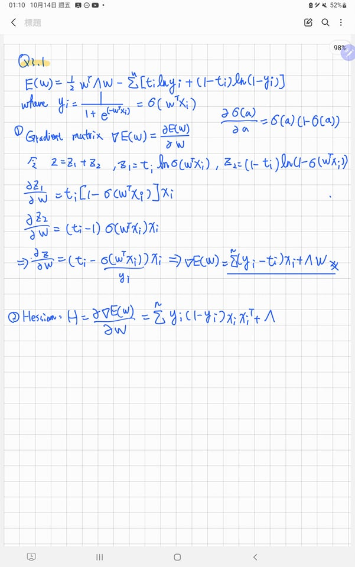

```python
from IPython.display import Image
Image(filename="D:/Users/User/Desktop/311049083_3429909157239049_4452138893094353684_n.jpg",width=600,height=900)
```

```python
# Q3.2
import pickle
from math import log
from sklearn import preprocessing
import numpy as np
from scipy.special import expit, logit
dsfile = "D:/Users/User/Desktop/adult_m50k.pickle"
with open(dsfile, 'rb') as fh1:
    adult50kp = pickle.load(fh1)

Y_train = adult50kp['y_train']
Y_test = adult50kp['y_test']
X_train = adult50kp['x_train']
X_test = adult50kp['x_test']
numcol = adult50kp['num_col']
columnname = adult50kp['columnname'].tolist()
```

```python
m,n = X_train.shape
lambda_vec = np.zeros(n)
```

```python
import math


class mylogistic_l2():
    def __init__(self, reg_vec, max_iter = 100, tol = 0.00001, add_intercept = True):
        """reg_vec: the regularization coefficient vector
           max_iter: maximum number of iteration to run for the Newton method
           tol: tolerance for the objective function
           add_intercept: whether to add intercept (a column of ones) at last column of the feature matrix"""
        self.reg_vec = reg_vec
        self.max_iter = 1000
        self.tol = tol
        self.add_intercept = add_intercept

    def fit(self, x, y, verbal = False):
        m, n = x.shape
        add = [1]*m
        add2 = np.array(add)
        # 依照題目限制更改lambda vector
        if self.add_intercept == True:
            x = np.column_stack((x, add2.T))

        if self.add_intercept == False:
            self.reg_vec = np.delete(self.reg_vec,-1,axis = 1)  #
        self.verbal = verbal
        self.m, self.n = x.shape #共有m列、n行
        self.w = np.zeros(self.n)
        self.m1, self.n2 = self.reg_vec.shape #103*103

        self.x = x
        self.y = y
        xx = self.x.T, self.y

        initial_w = np.dot(np.linalg.inv(np.dot(self.x.T, self.x)+np.dot(np.trace(self.reg_vec)/self.n2, np.eye(self.n))), np.dot(self.x.T, self.y))


        for i in range(self.max_iter):
            error_0 = 0
            if i == 0:
                w_old = initial_w
                for j in range(self.m):
                    sigmoid = 1 / (1 + np.exp(np.dot(-w_old.T, self.x[j])))
                    error_0 += self.y[j]*math.log(sigmoid) + (1-self.y[j])*math.log(1-sigmoid)
                error_old = np.dot(np.dot(w_old.T, self.reg_vec), w_old)/2 -error_0

            else:
                w_old = w_new
            Sigmoid = []
            Sigmoid_neg = []
            r = []

            for j in range(self.m):
                sigmoid = 1 / (1 + np.exp(np.dot(-w_old.T, self.x[j])))
                Sigmoid.append(sigmoid)
                sigmoid_neg = 1-sigmoid
                Sigmoid_neg.append(sigmoid_neg)
                error_0 += self.y[j]*math.log(sigmoid) + (1-self.y[j])*math.log(1-sigmoid)
            sigmoid_arr = np.array(Sigmoid)
            sigmoid_neg_arr = np.array(Sigmoid_neg)
            differ = sigmoid_arr - self.y
            difference = np.sum(differ)
            gradient = np.dot(self.reg_vec, w_old)+ np.dot(self.x.T, differ)
            R = np.zeros(self.x.shape[0])
            for j in range(self.x.shape[0]):
                R[j] = sigmoid_arr[j] * sigmoid_neg_arr[j]
            R = np.diag(R)

            hessian = np.dot(np.dot(self.x.T, R), self.x) + self.reg_vec
            w_new = w_old - np.dot(np.linalg.inv(hessian), gradient)
            # 計算error
            error_1 = 0
            for j in range(self.m):
                sigmoid = 1 / (1 + np.exp(np.dot(-w_new.T, self.x[j])))
                error_1 += self.y[j]*math.log(sigmoid) + (1-self.y[j])*math.log(1-sigmoid)
            error_new = np.dot(np.dot(w_new.T, self.reg_vec), w_new)/2 -error_1

            if abs(error_new-error_old) < self.tol:
                break
            error_old = error_new
        self.optimize_w = w_new
    def predict(self, x_test):
        """doing prediction"""
        m, n = x_test.shape
        add = [1]*m
        add2 = np.array(add)
        ypredlist = []
        if self.add_intercept == True:
            x_test = np.column_stack((x_test, add2.T))
        for i in range(m):
            sigmoidpred = 1 / (1 + np.exp(np.dot(-self.optimize_w.T, x_test[i])))
            if sigmoidpred > 0.5:
                sigmoidpred = 1
            else:
                sigmoidpred = 0

            ypredlist.append(sigmoidpred)
        ypred = np.array(ypredlist)
        # print(self.optimize_w)
        return ypred
    def tuning(self, x_subtrain, y_subtrain, x_tuning, y_tuning):
        self.fit(x_subtrain, y_subtrain)
        ypredtune = self.predict(x_tuning)
        correct = 0
        for i in range(y_tuning.shape[0]):
            if ypredtune[i] == y_tuning[i]:
                correct += 1
        accuracy = correct/y_tuning.shape[0]
        print(f'accuracy record: {accuracy}')
        return accuracy
```

```python
# case1
m,n = X_train.shape
lambda_vec = np.eye(n+1)
logic1 = mylogistic_l2(reg_vec = lambda_vec, max_iter = 1000, tol = 0.00001, add_intercept = True)
logic1.fit(X_train, Y_train)
ypred = logic1.predict(X_test)

my = Y_test.shape[0]
correct = 0
for i in range(my):
    if Y_test[i] == ypred[i]:
        correct += 1
print(f'case 1 accuracy: {correct/my}')
```

[output not shown]

```python
# case2
m,n = X_train.shape
lambda_vec = np.eye(n+1)
lambda_vec[n][n] = 0
logic1 = mylogistic_l2(reg_vec = lambda_vec, max_iter = 1000, tol = 1e-5, add_intercept = True)
logic1.fit(X_train, Y_train)
ypred2 = logic1.predict(X_test)
correct2 = 0
for i in range(my):
    if Y_test[i] == ypred2[i]:
        correct2 += 1
print(f'case 2 accuracy: {correct2/my}')
```

[output not shown]

```python
# case3
m,n = X_train.shape
lambda_vec = np.eye(n+1)
lambda_vec[n][n] = 0

lambda3 = []
lambda4 = []

for i in range(n):
    lambda4.append(i)
for i in numcol:
    for j in columnname:
        if i == j:
            a = columnname.index(j)
            lambda3.append(a)

for i in lambda4:
    if i not in lambda3:
        lambda_vec[i][i] = 0.5


logic1 = mylogistic_l2(reg_vec = lambda_vec, max_iter = 1000, tol = 1e-5, add_intercept = True)
logic1.fit(X_train, Y_train)
ypred3 = logic1.predict(X_test)
correct3 = 0
for i in range(my):
    if Y_test[i] == ypred3[i]:
        correct3 += 1
print(f'case 3 accuracy: {correct3/my}')
```

[output not shown]

```python
# test accuracy for 3 different case
my = Y_test.shape[0]
correct = 0
for i in range(my):
    if Y_test[i] == ypred[i]:
        correct += 1
print(correct)
print(f'case 1 accuracy: {correct/my}')

correct2 = 0
for i in range(my):
    if Y_test[i] == ypred2[i]:
        correct2 += 1
print(f'case 2 accuracy: {correct2/my}')

correct3 = 0
for i in range(my):
    if Y_test[i] == ypred3[i]:
        correct3 += 1
print(f'case 3 accuracy: {correct3/my}')
```

```
12769
case 1 accuracy: 0.847875166002656
case 2 accuracy: 0.8477423638778221
case 3 accuracy: 0.847675962815405
```

### Q3.3

split the training data into subtraining (90%) and tuning (10%)  
Set the regularization coefficient for the constant term to zero.  
Allow different regularizations for continuous-valued and binary-valued features

1. Choose a set of grids among a reasonable range. For example, 10 grids in [0.01, 100].
2. Conduct grid search with the constraint that a_1 = a_2. Record the best value a_1^ *and a_2^*.
3. Fix a_1 = a_1^*, and search a_2 for the best value, call the result the new a_2^*.
4. Fix a_2 = a_2^*, and search a_1 for the best value.
5. Report the selected $a_1$ and a_2.
6. Train a model using the selected hyper-parameters, and report the test accuracy.

```python
from sklearn.model_selection import train_test_split
X_subtrain, X_tune, Y_subtrain, Y_tune = train_test_split(X_train, Y_train, test_size=0.1)
```

```python
grid = [0.05, 0.2, 0.4, 0.65, 1, 1.5,2.5, 3.5, 6, 20]
for k in range(10):
    lambda111 = np.full((n+1,),grid[k])
    lambda_vec2 = np.diag(lambda111)
    lambda_vec2[n][n] = 0
    logic_tune = mylogistic_l2(reg_vec = lambda_vec2, max_iter = 1000, tol = 1e-5, add_intercept = True)
    accuracy = logic_tune.tuning(X_subtrain,Y_subtrain,X_tune,Y_tune)
    if k ==0:
        best_accuracy = accuracy
        bestlambda = grid[0]
    else:
        if best_accuracy <= accuracy:
           best_accuracy = accuracy
           bestlambda = grid[k]
           best_lambdavec = lambda_vec2
           fix_lambdavec = lambda_vec2
print(f'bestlambda,best_accuracy: {bestlambda,best_accuracy}')
```

```
accuracy record: 0.8574743122306927
accuracy record: 0.8581372224063639
accuracy record: 0.8584686774941995
accuracy record: 0.8584686774941995
accuracy record: 0.8588001325820351
accuracy record: 0.8588001325820351
accuracy record: 0.8581372224063639
accuracy record: 0.8578057673185283
accuracy record: 0.8578057673185283
accuracy record: 0.8554855817036792
bestlambda,best_accuracy: (1.5, 0.8588001325820351)
```

```python
for k in range(10):
    for i in lambda4:
        if i not in lambda3:
            best_lambdavec[i][i] = grid[k]
    best_lambdavec[n][n] = 0
    logic_tune = mylogistic_l2(reg_vec = best_lambdavec, max_iter = 1000, tol = 1e-5, add_intercept = True)
    accuracy = logic_tune.tuning(X_subtrain,Y_subtrain,X_tune,Y_tune)
    if k ==0:
        best_accuracy = accuracy
        best_a2lambda = grid[0]
    else:
        if best_accuracy <= accuracy:
            best_accuracy = accuracy
            best_a2lambda = grid[k]

print(f'best a2 lambda, best_accuracy: {best_a2lambda,best_accuracy}')
```

```
accuracy record: 0.8578057673185283
accuracy record: 0.8581372224063639
accuracy record: 0.8584686774941995
accuracy record: 0.8584686774941995
accuracy record: 0.8588001325820351
accuracy record: 0.8588001325820351
accuracy record: 0.8581372224063639
accuracy record: 0.8574743122306927
accuracy record: 0.8574743122306927
accuracy record: 0.8551541266158436
best a2 lambda, best_accuracy: (1.5, 0.8588001325820351)
```

```python
for k in range(10):
    for i in lambda4:
        if i in lambda3:
            fix_lambdavec[i][i] = grid[k]
        else:
            fix_lambdavec[i][i] = bestlambda
    fix_lambdavec[n][n] = 0
    logic_tune = mylogistic_l2(reg_vec = fix_lambdavec, max_iter = 1000, tol = 1e-5, add_intercept = True)
    accuracy = logic_tune.tuning(X_subtrain,Y_subtrain,X_tune,Y_tune)
    if k == 0:
        best_accuracy = accuracy
        best_a1lambda = grid[0]
    else:
        if best_accuracy <= accuracy:
            best_accuracy = accuracy
            best_a1lambda = grid[k]

print(f'best a1 lambda, best_accuracy: {best_a1lambda, best_accuracy}')
```

```
accuracy record: 0.8588001325820351
accuracy record: 0.8588001325820351
accuracy record: 0.8588001325820351
accuracy record: 0.8588001325820351
accuracy record: 0.8588001325820351
accuracy record: 0.8588001325820351
accuracy record: 0.8588001325820351
accuracy record: 0.8588001325820351
accuracy record: 0.8584686774941995
accuracy record: 0.8584686774941995
best a1 lambda, best_accuracy: (3.5, 0.8588001325820351)
```

```python
for i in lambda4:
    if i not in lambda3:
        lambda_vec[i][i] = best_a2lambda
    else:
        lambda_vec[i][i] = best_a1lambda
lambda_vec[n][n] = 0
logic1 = mylogistic_l2(reg_vec = lambda_vec, max_iter = 1000, tol = 1e-5, add_intercept = True)
logic1.fit(X_train, Y_train)
ypred2 = logic1.predict(X_test)
correct2 = 0
for i in range(my):
    if Y_test[i] == ypred2[i]:
        correct2 += 1
print(f'test accuracy: {correct2/my}')
print(f'best a1 lambda, best a2 lambda: {best_a1lambda, best_a2lambda}')
```

```
test accuracy: 0.84800796812749
best a1 lambda, best a2 lambda: (3.5, 1.5)
```

### Q3.4

```python
logic5 = LogisticRegression(penalty = 'l2', solver = 'newton-cg', max_iter = 1000, tol = 0.00001)
logic5.fit(X_train, Y_train)
ypred = logic5.predict(X_test)
my = Y_test.shape[0]
correct = 0
for i in range(my):
    if Y_test[i] == ypred[i]:
        correct += 1

print(f'套件 case accuracy: {correct/my}')
```

```
套件 case accuracy: 0.8477423638778221
```

由以上結果可以觀察到: 套件的accuracy優於case3(continuous-valued lambda不等於 binary-valued lambda)的accuracy，同等於case2(消除constant lambda)的accuracy  
，遜於case1(所有變數都有regularization)的accuracy，而經過tunning的accuracy則是五者中最高的。